# CSCI E-106:Assignment 8

### Due Date: November 16, 2020 at 7:20 pm EST

### Instructions

Students should submit their reports on Canvas. The report needs to clearly state what question is being solved, step-by-step walk-through solutions, and final answers clearly indicated. Please solve by hand where appropriate.

Please submit two files: (1) a R Markdown file (.Rmd extension) and (2) a PDF document, word, or html generated using knitr for the .Rmd file submitted in (1) where appropriate. Please, use RStudio Cloud for your solutions.

## Problem 1

Refer to the the Efficacy of Nosocomial Infection Control (SENIC) data set. The primary objective of the Study on was to determine whether infection surveillance and control programs have reduced the rates of nosocomial (hospitalacquired) infection in United States hospitals. This data set consists of a random sample of 113 hospitals selected from the original 338 hospitals surveyed. Each line of the dataset has an identification number and provides information on 11 variables for a single hospital. The data presented here are for the 1975-76 study period. (15 points, 5 points each)

a-) Second-order regression model is to be fitted for relating number of nurses (Y ) to available facilities and services (X).

```r
rm(list = ls())
setwd("~/OneDrive/courses/e106/e106_hes2020/HW/HW8")

library(olsrr)
# load data and check for NA
senic <- read.csv('SENIC.csv')
head(senic)
```

|  | Length.of.stay | Age | Infection.risk | Routine.culturing.ratio | Routine.chest.X.ray.ratio | Number.of.beds | Medical.school.affiliation | Region | Average.daily.census | Number.of.nurses | Available.facilities.and.services |
| --- | --- | --- | --- | --- | --- | --- | --- | --- | --- | --- | --- |
| 1 | 7.13 | 55.7 | 4.1 | 9.0 | 39.6 | 279 | 2 | 4 | 207 | 241 | 60 |
| 2 | 8.82 | 58.2 | 1.6 | 3.8 | 51.7 | 80 | 2 | 2 | 51 | 52 | 40 |
| 3 | 8.34 | 56.9 | 2.7 | 8.1 | 74.0 | 107 | 2 | 3 | 82 | 54 | 20 |
| 4 | 8.95 | 53.7 | 5.6 | 18.9 | 122.8 | 147 | 2 | 4 | 53 | 148 | 40 |
| 5 | 11.20 | 56.5 | 5.7 | 34.5 | 88.9 | 180 | 2 | 1 | 134 | 151 | 40 |
| 6 | 9.76 | 50.9 | 5.1 | 21.9 | 97.0 | 150 | 2 | 2 | 147 | 106 | 40 |

```r
str(senic)
```

```
## 'data.frame':    113 obs. of  11 variables:
##  $ Length.of.stay                   : num  7.13 8.82 8.34 8.95 11.2 ...
##  $ Age                              : num  55.7 58.2 56.9 53.7 56.5 50.9 57.8 45.7 48.2 56.3 ...
##  $ Infection.risk                   : num  4.1 1.6 2.7 5.6 5.7 5.1 4.6 5.4 4.3 6.3 ...
##  $ Routine.culturing.ratio          : num  9 3.8 8.1 18.9 34.5 21.9 16.7 60.5 24.4 29.6 ...
##  $ Routine.chest.X.ray.ratio        : num  39.6 51.7 74 122.8 88.9 ...
##  $ Number.of.beds                   : int  279 80 107 147 180 150 186 640 182 85 ...
##  $ Medical.school.affiliation       : int  2 2 2 2 2 2 2 1 2 2 ...
##  $ Region                           : int  4 2 3 4 1 2 3 2 3 1 ...
##  $ Average.daily.census             : int  207 51 82 53 134 147 151 399 130 59 ...
##  $ Number.of.nurses                 : int  241 52 54 148 151 106 129 360 118 66 ...
##  $ Available.facilities.and.services: num  60 40 20 40 40 40 40 60 40 40 ...
```

```r
y <- senic$Number.of.nurses
x1 <- senic$Available.facilities.and.services

# fit 1st order model
reg1a <- lm(y~x1+I(x1^2))
summary(reg1a)
```

```
##
## Call:
## lm(formula = y ~ x1 + I(x1^2))
##
## Residuals:
##     Min      1Q  Median      3Q     Max
## -244.32  -39.42   -4.55   26.48  336.48
##
## Coefficients:
##             Estimate Std. Error t value Pr(>|t|)
## (Intercept) 33.54823   51.41432   0.653  0.51544
## x1          -1.66613    2.43463  -0.684  0.49519
## I(x1^2)      0.10116    0.02723   3.716  0.00032 ***
## ---
## Signif. codes:  0 '***' 0.001 '**' 0.01 '*' 0.05 '.' 0.1 ' ' 1
##
## Residual standard error: 82.31 on 110 degrees of freedom
## Multiple R-squared:  0.6569, Adjusted R-squared:  0.6507
## F-statistic: 105.3 on 2 and 110 DF,  p-value: < 2.2e-16
```

b-) Fit the second-order regression model. Plot the residuals against the fitted values. How well does the second-order model appear to fit the data?

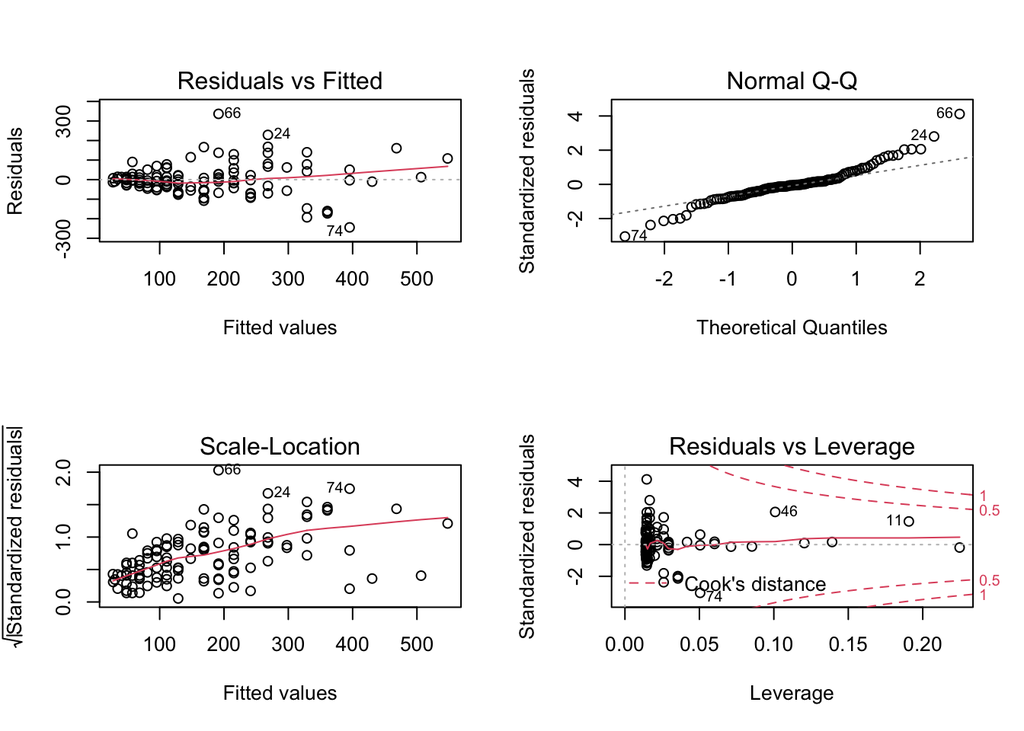

```r
# residuals vs fitted plots
newer.par = par(mfrow = c(2,2))
plot(reg1a)
```

```r
newer.par
```

```
## $mfrow
## [1] 1 1
```

From the regression summary above we see that the overall regression has a p-value <2.2e-16 and F-stat of 105.3 and is significant for an R2 of 0.6569. The variable for availabile facilities and services is not significant with p-value > 0.49 while the square term is significant with p-value = 0.00032

The residual vs fitted values plot show divergence for increasing amount of fitted values while the QQ plot line is not at 45 degrees. The standardized residual and theoretical quantities values plot track each other for only +/- 1 SD

This means that following key regression assumptions are not satisfied

1. Linearity of regression function
2. Error terms have constant variance
3. Error terms are normally distributed
4. Error terms are independent

c-) Test whether the quadratic term can be dropped from the regression model; use $\alpha$=0.1, State the alternatives, decision rule, and conclusion.

```r
# reduced model
reg1c <- lm(y~x1)

# anova test
anova(reg1c, reg1a)
```

|  | Res.Df | RSS | Df | Sum of Sq | F | Pr(>F) |
| --- | --- | --- | --- | --- | --- | --- |
| 1 | 111 | 838736.9 | NA | NA | NA | NA |
| 2 | 110 | 745203.6 | 1 | 93533.25 | 13.8065 | 0.0003202726 |

Ho : Quadratic term is not needed. Ha : Quadratic term is needed.

ANOVA test above shows that full model adds 93533 units to the sum of squares and p-value = 0.0003203 which means that the result is significant at 5% level of significance.

Hence, we reject Ho and conclude that the quadratic term is needed.

## Problem 2

Use the fortune data under the faraway r library, data(prostate,package=“faraway”). Use the prostate data with lpsa as the response and the other variables as predictors.

Implement the following variable selection methods to determine the “best” model: (40 points, 10 points each)

a-) Backward elimination

```r
# load and check for NA
data(prostate, package = 'faraway')
head(prostate)
```

|  | lcavol | lweight | age | lbph | svi | lcp | gleason | pgg45 | lpsa |
| --- | --- | --- | --- | --- | --- | --- | --- | --- | --- |
| 1 | -0.5798185 | 2.7695 | 50 | -1.386294 | 0 | -1.38629 | 6 | 0 | -0.43078 |
| 2 | -0.9942523 | 3.3196 | 58 | -1.386294 | 0 | -1.38629 | 6 | 0 | -0.16252 |
| 3 | -0.5108256 | 2.6912 | 74 | -1.386294 | 0 | -1.38629 | 7 | 20 | -0.16252 |
| 4 | -1.2039728 | 3.2828 | 58 | -1.386294 | 0 | -1.38629 | 6 | 0 | -0.16252 |
| 5 | 0.7514161 | 3.4324 | 62 | -1.386294 | 0 | -1.38629 | 6 | 0 | 0.37156 |
| 6 | -1.0498221 | 3.2288 | 50 | -1.386294 | 0 | -1.38629 | 6 | 0 | 0.76547 |

```r
summary(prostate)
```

```
##      lcavol           lweight           age             lbph
##  Min.   :-1.3471   Min.   :2.375   Min.   :41.00   Min.   :-1.3863
##  1st Qu.: 0.5128   1st Qu.:3.376   1st Qu.:60.00   1st Qu.:-1.3863
##  Median : 1.4469   Median :3.623   Median :65.00   Median : 0.3001
##  Mean   : 1.3500   Mean   :3.653   Mean   :63.87   Mean   : 0.1004
##  3rd Qu.: 2.1270   3rd Qu.:3.878   3rd Qu.:68.00   3rd Qu.: 1.5581
##  Max.   : 3.8210   Max.   :6.108   Max.   :79.00   Max.   : 2.3263
##       svi              lcp             gleason          pgg45
##  Min.   :0.0000   Min.   :-1.3863   Min.   :6.000   Min.   :  0.00
##  1st Qu.:0.0000   1st Qu.:-1.3863   1st Qu.:6.000   1st Qu.:  0.00
##  Median :0.0000   Median :-0.7985   Median :7.000   Median : 15.00
##  Mean   :0.2165   Mean   :-0.1794   Mean   :6.753   Mean   : 24.38
##  3rd Qu.:0.0000   3rd Qu.: 1.1786   3rd Qu.:7.000   3rd Qu.: 40.00
##  Max.   :1.0000   Max.   : 2.9042   Max.   :9.000   Max.   :100.00
##       lpsa
##  Min.   :-0.4308
##  1st Qu.: 1.7317
##  Median : 2.5915
##  Mean   : 2.4784
##  3rd Qu.: 3.0564
##  Max.   : 5.5829
```

```r
str(prostate)
```

```
## 'data.frame':    97 obs. of  9 variables:
##  $ lcavol : num  -0.58 -0.994 -0.511 -1.204 0.751 ...
##  $ lweight: num  2.77 3.32 2.69 3.28 3.43 ...
##  $ age    : int  50 58 74 58 62 50 64 58 47 63 ...
##  $ lbph   : num  -1.39 -1.39 -1.39 -1.39 -1.39 ...
##  $ svi    : int  0 0 0 0 0 0 0 0 0 0 ...
##  $ lcp    : num  -1.39 -1.39 -1.39 -1.39 -1.39 ...
##  $ gleason: int  6 6 7 6 6 6 6 6 6 6 ...
##  $ pgg45  : int  0 0 20 0 0 0 0 0 0 0 ...
##  $ lpsa   : num  -0.431 -0.163 -0.163 -0.163 0.372 ...
```

```r
set.seed(1023)

# fit full model
reg2a <- lm(lpsa~., data = prostate)
summary(reg2a)
```

```
##
## Call:
## lm(formula = lpsa ~ ., data = prostate)
##
## Residuals:
##     Min      1Q  Median      3Q     Max
## -1.7331 -0.3713 -0.0170  0.4141  1.6381
##
## Coefficients:
##              Estimate Std. Error t value Pr(>|t|)
## (Intercept)  0.669337   1.296387   0.516  0.60693
## lcavol       0.587022   0.087920   6.677 2.11e-09 ***
## lweight      0.454467   0.170012   2.673  0.00896 **
## age         -0.019637   0.011173  -1.758  0.08229 .
## lbph         0.107054   0.058449   1.832  0.07040 .
## svi          0.766157   0.244309   3.136  0.00233 **
## lcp         -0.105474   0.091013  -1.159  0.24964
## gleason      0.045142   0.157465   0.287  0.77503
## pgg45        0.004525   0.004421   1.024  0.30886
## ---
## Signif. codes:  0 '***' 0.001 '**' 0.01 '*' 0.05 '.' 0.1 ' ' 1
##
## Residual standard error: 0.7084 on 88 degrees of freedom
## Multiple R-squared:  0.6548, Adjusted R-squared:  0.6234
## F-statistic: 20.86 on 8 and 88 DF,  p-value: < 2.2e-16
```

```r
# find best model from backward elimination
prost_backward_step <- ols_step_backward_p(reg2a, prem = 0.05, details = TRUE)
```

```
## Backward Elimination Method
## ---------------------------
##
## Candidate Terms:
##
## 1 . lcavol
## 2 . lweight
## 3 . age
## 4 . lbph
## 5 . svi
## 6 . lcp
## 7 . gleason
## 8 . pgg45
##
## We are eliminating variables based on p value...
##
## - gleason
##
## Backward Elimination: Step 1
##
##  Variable gleason Removed
##
##                         Model Summary
## --------------------------------------------------------------
## R                       0.809       RMSE                0.705
## R-Squared               0.654       Coef. Var          28.436
## Adj. R-Squared          0.627       MSE                 0.497
## Pred R-Squared          0.584       MAE                 0.521
## --------------------------------------------------------------
##  RMSE: Root Mean Square Error
##  MSE: Mean Square Error
##  MAE: Mean Absolute Error
##
##                                ANOVA
## -------------------------------------------------------------------
##                Sum of
##               Squares        DF    Mean Square      F         Sig.
## -------------------------------------------------------------------
## Regression     83.713         7         11.959    24.078    0.0000
## Residual       44.204        89          0.497
```

[output cut: 207 more lines]

```
## -------------------------------------------------------------------
## Regression     80.133         3         26.711    51.985    0.0000
## Residual       47.785        93          0.514
## Total         127.918        96
## -------------------------------------------------------------------
##
##                                   Parameter Estimates
## ---------------------------------------------------------------------------------------
##       model      Beta    Std. Error    Std. Beta      t        Sig      lower    upper
## ---------------------------------------------------------------------------------------
## (Intercept)    -0.268         0.543                 -0.493    0.623    -1.347    0.811
##      lcavol     0.552         0.075        0.563     7.388    0.000     0.403    0.700
##     lweight     0.509         0.150        0.219     3.386    0.001     0.210    0.807
##         svi     0.666         0.210        0.239     3.176    0.002     0.250    1.083
## ---------------------------------------------------------------------------------------
```

```r
prost_backward_step
```

```
##
##
##                           Elimination Summary
## ------------------------------------------------------------------------
##         Variable                  Adj.
## Step    Removed     R-Square    R-Square     C(p)       AIC        RMSE
## ------------------------------------------------------------------------
##    1    gleason       0.6544      0.6273    7.0822    217.0428    0.7048
##    2    lcp           0.6493      0.6259    6.4020    216.4854    0.7061
##    3    pgg45         0.6441      0.6245    5.7150    215.8997    0.7073
##    4    age           0.6366      0.6208    5.6264    215.9223    0.7108
##    5    lbph          0.6264      0.6144    6.2169    216.5979    0.7168
## ------------------------------------------------------------------------
```

```r
# create df with names identified in backward step removed
prost_backward_df <- prostate[,!names(prostate) %in% prost_backward_step$removed]
head(prost_backward_df)
```

|  | lcavol | lweight | svi | lpsa |
| --- | --- | --- | --- | --- |
| 1 | -0.5798185 | 2.7695 | 0 | -0.43078 |
| 2 | -0.9942523 | 3.3196 | 0 | -0.16252 |
| 3 | -0.5108256 | 2.6912 | 0 | -0.16252 |
| 4 | -1.2039728 | 3.2828 | 0 | -0.16252 |
| 5 | 0.7514161 | 3.4324 | 0 | 0.37156 |
| 6 | -1.0498221 | 3.2288 | 0 | 0.76547 |

```r
str(prost_backward_df)
```

```
## 'data.frame':    97 obs. of  4 variables:
##  $ lcavol : num  -0.58 -0.994 -0.511 -1.204 0.751 ...
##  $ lweight: num  2.77 3.32 2.69 3.28 3.43 ...
##  $ svi    : int  0 0 0 0 0 0 0 0 0 0 ...
##  $ lpsa   : num  -0.431 -0.163 -0.163 -0.163 0.372 ...
```

```r
summary(prost_backward_df)
```

```
##      lcavol           lweight           svi              lpsa
##  Min.   :-1.3471   Min.   :2.375   Min.   :0.0000   Min.   :-0.4308
##  1st Qu.: 0.5128   1st Qu.:3.376   1st Qu.:0.0000   1st Qu.: 1.7317
##  Median : 1.4469   Median :3.623   Median :0.0000   Median : 2.5915
##  Mean   : 1.3500   Mean   :3.653   Mean   :0.2165   Mean   : 2.4784
##  3rd Qu.: 2.1270   3rd Qu.:3.878   3rd Qu.:0.0000   3rd Qu.: 3.0564
##  Max.   : 3.8210   Max.   :6.108   Max.   :1.0000   Max.   : 5.5829
```

```r
# fit the regression model
reg_prost_backward <- lm(lpsa~., data = prost_backward_df)
summary(reg_prost_backward)
```

```
##
## Call:
## lm(formula = lpsa ~ ., data = prost_backward_df)
##
## Residuals:
##      Min       1Q   Median       3Q      Max
## -1.72964 -0.45764  0.02812  0.46403  1.57013
##
## Coefficients:
##             Estimate Std. Error t value Pr(>|t|)
## (Intercept) -0.26809    0.54350  -0.493  0.62298
## lcavol       0.55164    0.07467   7.388  6.3e-11 ***
## lweight      0.50854    0.15017   3.386  0.00104 **
## svi          0.66616    0.20978   3.176  0.00203 **
## ---
## Signif. codes:  0 '***' 0.001 '**' 0.01 '*' 0.05 '.' 0.1 ' ' 1
##
## Residual standard error: 0.7168 on 93 degrees of freedom
## Multiple R-squared:  0.6264, Adjusted R-squared:  0.6144
## F-statistic: 51.99 on 3 and 93 DF,  p-value: < 2.2e-16
```

b-) AIC

```r
# perform best subset selection
r1 <- ols_step_best_subset(reg2a, details = TRUE)
r1
```

|  | mindex | n | predictors | rsquare | adjr | predrsq | cp | aic | sbic | sbc | msep | fpe | apc | hsp |
| --- | --- | --- | --- | --- | --- | --- | --- | --- | --- | --- | --- | --- | --- | --- |
| 1 | 1 | 1 | lcavol | 0.5394319 | 0.5345838 | 0.5179245 | 24.394559 | 232.9080 | -43.12135 | 240.6321 | 60.15534 | 0.6329421 | 0.4799604 | 0.006597397 |
| 9 | 2 | 2 | lcavol lweight | 0.5859345 | 0.5771246 | 0.5534004 | 14.541475 | 224.5837 | -51.18910 | 234.8825 | 54.66310 | 0.5808977 | 0.4404952 | 0.006058826 |
| 39 | 3 | 3 | lcavol lweight svi | 0.6264403 | 0.6143899 | 0.5868642 | 6.216935 | 216.5979 | -58.52710 | 229.4714 | 49.85175 | 0.5350040 | 0.4056939 | 0.005584953 |
| 98 | 4 | 4 | lcavol lweight lbph svi | 0.6366035 | 0.6208036 | 0.5897527 | 5.626422 | 215.9223 | -58.88408 | 231.3705 | 49.02838 | 0.5313144 | 0.4028961 | 0.005552413 |
| 163 | 5 | 5 | lcavol lweight age lbph svi | 0.6441024 | 0.6245476 | 0.5882308 | 5.715016 | 215.8997 | -58.55260 | 233.9227 | 48.55017 | 0.5312261 | 0.4028292 | 0.005558677 |
| 221 | 6 | 6 | lcavol lweight age lbph svi pgg45 | 0.6492538 | 0.6258707 | 0.5856278 | 6.401965 | 216.4854 | -57.61330 | 237.0831 | 48.38504 | 0.5344933 | 0.4053067 | 0.005601324 |
| 248 | 7 | 7 | lcavol lweight age lbph svi lcp pgg45 | 0.6544317 | 0.6272521 | 0.5835286 | 7.082184 | 217.0428 | -56.63189 | 240.2152 | 48.21248 | 0.5376402 | 0.4076930 | 0.005644059 |
| 255 | 8 | 8 | lcavol lweight age lbph svi lcp gleason pgg45 | 0.6547541 | 0.6233681 | 0.5760359 | 9.000000 | 218.9522 | -54.50185 | 244.6993 | 48.72115 | 0.5484162 | 0.4158644 | 0.005768420 |

Above we have the best subset regression with values for each of the selection methods. We now proceed to choose the model based on the method specified.

```r
# get model number with minimum AIC
r1$aic
```

```
## [1] 232.9080 224.5837 216.5979 215.9223 215.8997 216.4854 217.0428 218.9522
```

```r
min_aic <- which.min(r1$aic)
min_aic
```

```
## [1] 5
```

```r
# df with columns for model with minimum AIC
# index according to min_aic value, returns string which is split on space to list and unlist the same
aic_df_cols <- unlist(strsplit(r1$predictors[min_aic], split = ' '))
aic_df_cols
```

```
## [1] "lcavol"  "lweight" "age"     "lbph"    "svi"
```

```r
prost_aic_df <- prostate[aic_df_cols]

# add response variable and verify structure
lpsa <- prostate$lpsa
prost_aic_df <- cbind(lpsa, prost_aic_df)
str(prost_aic_df)
```

```
## 'data.frame':    97 obs. of  6 variables:
##  $ lpsa   : num  -0.431 -0.163 -0.163 -0.163 0.372 ...
##  $ lcavol : num  -0.58 -0.994 -0.511 -1.204 0.751 ...
##  $ lweight: num  2.77 3.32 2.69 3.28 3.43 ...
##  $ age    : int  50 58 74 58 62 50 64 58 47 63 ...
##  $ lbph   : num  -1.39 -1.39 -1.39 -1.39 -1.39 ...
##  $ svi    : int  0 0 0 0 0 0 0 0 0 0 ...
```

```r
# run regression with shortlisted columns
reg_prost_aic <- lm(lpsa~., data = prost_aic_df)
summary(reg_prost_aic)
```

```
##
## Call:
## lm(formula = lpsa ~ ., data = prost_aic_df)
##
## Residuals:
##      Min       1Q   Median       3Q      Max
## -1.83505 -0.39396  0.00414  0.46336  1.57888
##
## Coefficients:
##             Estimate Std. Error t value Pr(>|t|)
## (Intercept)  0.95100    0.83175   1.143 0.255882
## lcavol       0.56561    0.07459   7.583 2.77e-11 ***
## lweight      0.42369    0.16687   2.539 0.012814 *
## age         -0.01489    0.01075  -1.385 0.169528
## lbph         0.11184    0.05805   1.927 0.057160 .
## svi          0.72095    0.20902   3.449 0.000854 ***
## ---
## Signif. codes:  0 '***' 0.001 '**' 0.01 '*' 0.05 '.' 0.1 ' ' 1
##
## Residual standard error: 0.7073 on 91 degrees of freedom
## Multiple R-squared:  0.6441, Adjusted R-squared:  0.6245
## F-statistic: 32.94 on 5 and 91 DF,  p-value: < 2.2e-16
```

c-) Adjusted $R_a^2$

```r
# get model number with max Adj R2
r1$adjr
```

```
## [1] 0.5345838 0.5771246 0.6143899 0.6208036 0.6245476 0.6258707 0.6272521
## [8] 0.6233681
```

```r
max_adjr2 <- which.max(r1$adjr)
max_adjr2
```

```
## [1] 7
```

```r
# df with columns for model with max adj R2
# index according to max_adjR2 value, returns string which is split on space to list and unlist the same
adjr2_df_cols <- unlist(strsplit(r1$predictors[max_adjr2], split = ' '))
adjr2_df_cols
```

```
## [1] "lcavol"  "lweight" "age"     "lbph"    "svi"     "lcp"     "pgg45"
```

```r
prost_adjr2_df <- prostate[adjr2_df_cols]

# add response variable and verify structure
lpsa <- prostate$lpsa
prost_adjr2_df <- cbind(lpsa, prost_adjr2_df)
str(prost_adjr2_df)
```

```
## 'data.frame':    97 obs. of  8 variables:
##  $ lpsa   : num  -0.431 -0.163 -0.163 -0.163 0.372 ...
##  $ lcavol : num  -0.58 -0.994 -0.511 -1.204 0.751 ...
##  $ lweight: num  2.77 3.32 2.69 3.28 3.43 ...
##  $ age    : int  50 58 74 58 62 50 64 58 47 63 ...
##  $ lbph   : num  -1.39 -1.39 -1.39 -1.39 -1.39 ...
##  $ svi    : int  0 0 0 0 0 0 0 0 0 0 ...
##  $ lcp    : num  -1.39 -1.39 -1.39 -1.39 -1.39 ...
##  $ pgg45  : int  0 0 20 0 0 0 0 0 0 0 ...
```

```r
# run regression with shortlisted columns
reg_prost_adjr2 <- lm(lpsa~., data = prost_adjr2_df)
summary(reg_prost_adjr2)
```

```
##
## Call:
## lm(formula = lpsa ~ ., data = prost_adjr2_df)
##
## Residuals:
##      Min       1Q   Median       3Q      Max
## -1.73117 -0.38137 -0.01728  0.43364  1.63513
##
## Coefficients:
##              Estimate Std. Error t value Pr(>|t|)
## (Intercept)  0.953926   0.829439   1.150  0.25319
## lcavol       0.591615   0.086001   6.879 8.07e-10 ***
## lweight      0.448292   0.167771   2.672  0.00897 **
## age         -0.019336   0.011066  -1.747  0.08402 .
## lbph         0.107671   0.058108   1.853  0.06720 .
## svi          0.757734   0.241282   3.140  0.00229 **
## lcp         -0.104482   0.090478  -1.155  0.25127
## pgg45        0.005318   0.003433   1.549  0.12488
## ---
## Signif. codes:  0 '***' 0.001 '**' 0.01 '*' 0.05 '.' 0.1 ' ' 1
##
## Residual standard error: 0.7048 on 89 degrees of freedom
## Multiple R-squared:  0.6544, Adjusted R-squared:  0.6273
## F-statistic: 24.08 on 7 and 89 DF,  p-value: < 2.2e-16
```

d-) Mallows $C_p$

```r
# get model number with minimum Cp
r1$cp
```

```
## [1] 24.394559 14.541475  6.216935  5.626422  5.715016  6.401965  7.082184
## [8]  9.000000
```

```r
min_cp <- which.min(r1$cp)
min_cp
```

```
## [1] 4
```

```r
# df with columns for model with minimum Cp
# index according to min_cp value, returns string which is split on space to list and unlist the same
cp_df_cols <- unlist(strsplit(r1$predictors[min_cp], split = ' '))
cp_df_cols
```

```
## [1] "lcavol"  "lweight" "lbph"    "svi"
```

```r
prost_cp_df <- prostate[cp_df_cols]

# add response variable and verify structure
lpsa <- prostate$lpsa
prost_cp_df <- cbind(lpsa, prost_cp_df)
str(prost_cp_df)
```

```
## 'data.frame':    97 obs. of  5 variables:
##  $ lpsa   : num  -0.431 -0.163 -0.163 -0.163 0.372 ...
##  $ lcavol : num  -0.58 -0.994 -0.511 -1.204 0.751 ...
##  $ lweight: num  2.77 3.32 2.69 3.28 3.43 ...
##  $ lbph   : num  -1.39 -1.39 -1.39 -1.39 -1.39 ...
##  $ svi    : int  0 0 0 0 0 0 0 0 0 0 ...
```

```r
# run regression with shortlisted columns
reg_prost_cp <- lm(lpsa~., data = prost_cp_df)
summary(reg_prost_cp)
```

```
##
## Call:
## lm(formula = lpsa ~ ., data = prost_cp_df)
##
## Residuals:
##      Min       1Q   Median       3Q      Max
## -1.82653 -0.42270  0.04362  0.47041  1.48530
##
## Coefficients:
##             Estimate Std. Error t value Pr(>|t|)
## (Intercept)  0.14554    0.59747   0.244  0.80809
## lcavol       0.54960    0.07406   7.422 5.64e-11 ***
## lweight      0.39088    0.16600   2.355  0.02067 *
## lbph         0.09009    0.05617   1.604  0.11213
## svi          0.71174    0.20996   3.390  0.00103 **
## ---
## Signif. codes:  0 '***' 0.001 '**' 0.01 '*' 0.05 '.' 0.1 ' ' 1
##
## Residual standard error: 0.7108 on 92 degrees of freedom
## Multiple R-squared:  0.6366, Adjusted R-squared:  0.6208
## F-statistic: 40.29 on 4 and 92 DF,  p-value: < 2.2e-16
```

## Problem 3

Refer to the SENIC data set in problem 1. Length of stay (Y) is to be predicted, and the pool of potential predictor variables includes all other variables in the data set except medical school affiliation and region. It is believed that a model with $log(Y)$ as the response variable and the predictor variables in first-order terms with no interaction terms will be appropriate. Consider cases 57-113 to constitute the model-building data set to be used for the following analyses.(45 points, 9 points each)

a-) Prepare separate dot plots for each of the predictor variables. Are there any noteworthy features in these plots? Comment.

```r
# build df
str(senic)
```

```
## 'data.frame':    113 obs. of  11 variables:
##  $ Length.of.stay                   : num  7.13 8.82 8.34 8.95 11.2 ...
##  $ Age                              : num  55.7 58.2 56.9 53.7 56.5 50.9 57.8 45.7 48.2 56.3 ...
##  $ Infection.risk                   : num  4.1 1.6 2.7 5.6 5.7 5.1 4.6 5.4 4.3 6.3 ...
##  $ Routine.culturing.ratio          : num  9 3.8 8.1 18.9 34.5 21.9 16.7 60.5 24.4 29.6 ...
##  $ Routine.chest.X.ray.ratio        : num  39.6 51.7 74 122.8 88.9 ...
##  $ Number.of.beds                   : int  279 80 107 147 180 150 186 640 182 85 ...
##  $ Medical.school.affiliation       : int  2 2 2 2 2 2 2 1 2 2 ...
##  $ Region                           : int  4 2 3 4 1 2 3 2 3 1 ...
##  $ Average.daily.census             : int  207 51 82 53 134 147 151 399 130 59 ...
##  $ Number.of.nurses                 : int  241 52 54 148 151 106 129 360 118 66 ...
##  $ Available.facilities.and.services: num  60 40 20 40 40 40 40 60 40 40 ...
```

```r
senic$y <- log(senic$Length.of.stay) # add log
senic_p3 <- subset(senic, select = -c(Medical.school.affiliation, Region, Length.of.stay)) # drop columns not needed
senic_p3build <- senic_p3[57:113,] # model building dataset
head(senic_p3build)
```

|  | Age | Infection.risk | Routine.culturing.ratio | Routine.chest.X.ray.ratio | Number.of.beds | Average.daily.census | Number.of.nurses | Available.facilities.and.services | y |
| --- | --- | --- | --- | --- | --- | --- | --- | --- | --- |
| 57 | 59.0 | 3.7 | 2.6 | 75.8 | 70 | 37 | 35 | 31.4 | 1.965713 |
| 58 | 47.1 | 4.3 | 16.4 | 65.7 | 318 | 265 | 314 | 51.4 | 2.034706 |
| 59 | 50.6 | 3.9 | 19.3 | 101.0 | 445 | 374 | 345 | 51.4 | 2.373044 |
| 60 | 56.9 | 4.5 | 15.6 | 97.7 | 191 | 153 | 132 | 31.4 | 2.438863 |
| 61 | 58.0 | 3.4 | 8.0 | 59.0 | 119 | 67 | 64 | 31.4 | 2.343727 |
| 62 | 51.0 | 5.7 | 18.8 | 55.9 | 595 | 546 | 392 | 68.6 | 2.414126 |

```r
str(senic_p3build)
```

```
## 'data.frame':    57 obs. of  9 variables:
##  $ Age                              : num  59 47.1 50.6 56.9 58 51 64.1 52.1 45.5 50.6 ...
##  $ Infection.risk                   : num  3.7 4.3 3.9 4.5 3.4 5.7 5.4 4.4 5 4.3 ...
##  $ Routine.culturing.ratio          : num  2.6 16.4 19.3 15.6 8 18.8 7.5 9.9 20.9 24.8 ...
##  $ Routine.chest.X.ray.ratio        : num  75.8 65.7 101 97.7 59 55.9 98.1 98.3 71.6 62.8 ...
##  $ Number.of.beds                   : int  70 318 445 191 119 595 68 83 489 508 ...
##  $ Average.daily.census             : int  37 265 374 153 67 546 42 66 391 421 ...
##  $ Number.of.nurses                 : int  35 314 345 132 64 392 49 95 329 528 ...
##  $ Available.facilities.and.services: num  31.4 51.4 51.4 31.4 31.4 68.6 28.6 28.6 48.6 48.6 ...
##  $ y                                : num  1.97 2.03 2.37 2.44 2.34 ...
```

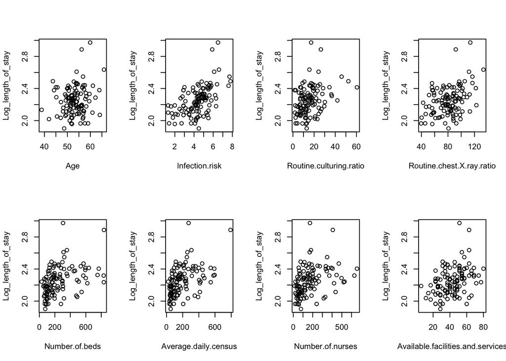

```r
# senic_p3hold <- senic[!(senic$y %in% senic_p3build$y),]
senic_p3hold <- senic_p3[1:56,]

# dot plots
newer.par = par(mfrow = c(2,4))
for (i in 1:(ncol(senic_p3)-1)) {
  #print(i)
  plot(senic_p3[,i],senic_p3$y, xlab = colnames(senic_p3)[i], ylab = 'Log_length_of_stay')
}
```

```r
newer.par
```

```
## $mfrow
## [1] 1 1
```

Most of the features seem to vary in a non-linear fashion wit the response variable - log(length of stay). There is some semblance of linearity in Infection.risk Number.of.nurses and Routine.chest.X.ray.ratio. However, the linear relationships appear to be weak and we should explore transformation of most predictors as well as potential interactions.

b-) Obtain the scatter plot matrix. Also obtain the correlation matrix of the X variables. Is there evidence of strong linear pairwise associations among the predictor variables here?

```r
print(round(cor(senic_p3build),3))
```

```
##                                      Age Infection.risk Routine.culturing.ratio
## Age                                1.000          0.025                  -0.101
## Infection.risk                     0.025          1.000                   0.448
## Routine.culturing.ratio           -0.101          0.448                   1.000
## Routine.chest.X.ray.ratio          0.161          0.334                   0.195
## Number.of.beds                    -0.198          0.490                   0.168
## Average.daily.census              -0.172          0.501                   0.204
## Number.of.nurses                  -0.236          0.530                   0.239
## Available.facilities.and.services -0.164          0.453                   0.240
## y                                  0.171          0.471                   0.255
##                                   Routine.chest.X.ray.ratio Number.of.beds
## Age                                                   0.161         -0.198
## Infection.risk                                        0.334          0.490
## Routine.culturing.ratio                               0.195          0.168
## Routine.chest.X.ray.ratio                             1.000          0.067
## Number.of.beds                                        0.067          1.000
## Average.daily.census                                  0.086          0.990
## Number.of.nurses                                      0.060          0.909
## Available.facilities.and.services                     0.128          0.764
## y                                                     0.364          0.574
##                                   Average.daily.census Number.of.nurses
## Age                                             -0.172           -0.236
## Infection.risk                                   0.501            0.530
## Routine.culturing.ratio                          0.204            0.239
## Routine.chest.X.ray.ratio                        0.086            0.060
## Number.of.beds                                   0.990            0.909
## Average.daily.census                             1.000            0.904
## Number.of.nurses                                 0.904            1.000
## Available.facilities.and.services                0.729            0.707
## y                                                0.608            0.470
##                                   Available.facilities.and.services     y
## Age                                                          -0.164 0.171
## Infection.risk                                                0.453 0.471
## Routine.culturing.ratio                                       0.240 0.255
## Routine.chest.X.ray.ratio                                     0.128 0.364
## Number.of.beds                                                0.764 0.574
## Average.daily.census                                          0.729 0.608
## Number.of.nurses                                              0.707 0.470
## Available.facilities.and.services                             1.000 0.404
## y                                                             0.404 1.000
```

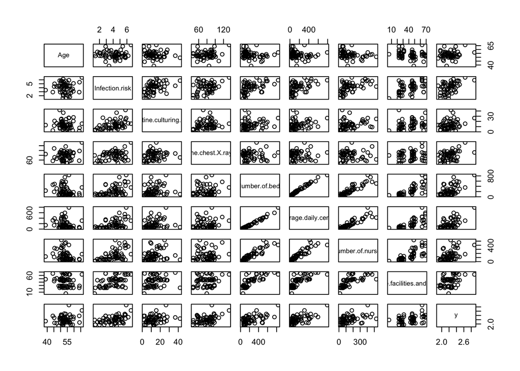

```r
plot(senic_p3build)
```

c-) Obtain the three best subsets according to the $C_p$ criterion, Which of these subset models appears to have the smallest bias?

```r
# build regression model
reg3c <- lm(y~.,data = senic_p3build)
summary(reg3c)
```

```
##
## Call:
## lm(formula = y ~ ., data = senic_p3build)
##
## Residuals:
##      Min       1Q   Median       3Q      Max
## -0.24089 -0.09860  0.02201  0.07416  0.23924
##
## Coefficients:
##                                     Estimate Std. Error t value Pr(>|t|)
## (Intercept)                        1.5025106  0.2235857   6.720 1.98e-08 ***
## Age                                0.0073991  0.0039544   1.871   0.0674 .
## Infection.risk                     0.0153783  0.0183060   0.840   0.4050
## Routine.culturing.ratio            0.0017961  0.0024909   0.721   0.4744
## Routine.chest.X.ray.ratio          0.0022312  0.0010354   2.155   0.0362 *
## Number.of.beds                    -0.0003268  0.0008026  -0.407   0.6857
## Average.daily.census               0.0013606  0.0008385   1.623   0.1112
## Number.of.nurses                  -0.0004968  0.0003383  -1.469   0.1485
## Available.facilities.and.services -0.0008081  0.0018835  -0.429   0.6698
## ---
## Signif. codes:  0 '***' 0.001 '**' 0.01 '*' 0.05 '.' 0.1 ' ' 1
##
## Residual standard error: 0.1275 on 48 degrees of freedom
## Multiple R-squared:  0.563,  Adjusted R-squared:  0.4901
## F-statistic: 7.729 on 8 and 48 DF,  p-value: 1.352e-06
```

```r
# perform best subset selection
b1 <- ols_step_best_subset(reg3c, details = TRUE)
b1
```

|  | mindex | n | predictors | rsquare | adjr | predrsq | cp | aic | sbic | sbc | msep | fpe | apc | hsp |
| --- | --- | --- | --- | --- | --- | --- | --- | --- | --- | --- | --- | --- | --- | --- |
| 6 | 1 | 1 | Average.daily.census | 0.3696475 | 0.3581866 | 0.2968446 | 16.232900 | -55.99347 | -218.5217 | -49.86432 | 1.1656866 | 0.02116773 | 0.6761963 | 0.0003787070 |
| 28 | 2 | 2 | Routine.chest.X.ray.ratio Average.daily.census | 0.4675593 | 0.4478393 | 0.3848787 | 7.479045 | -63.61551 | -225.5275 | -55.44331 | 1.0031998 | 0.01851954 | 0.5916007 | 0.0003319540 |
| 49 | 3 | 3 | Age Routine.chest.X.ray.ratio Average.daily.census | 0.5191640 | 0.4919468 | 0.4244062 | 3.811204 | -67.42639 | -228.5634 | -57.21113 | 0.9233913 | 0.01732417 | 0.5534151 | 0.0003113107 |
| 121 | 4 | 4 | Age Routine.chest.X.ray.ratio Average.daily.census Number.of.nurses | 0.5368943 | 0.5012708 | 0.4324186 | 3.863841 | -67.56794 | -228.1496 | -55.30963 | 0.9067802 | 0.01728502 | 0.5521644 | 0.0003115895 |
| 186 | 5 | 5 | Age Routine.culturing.ratio Routine.chest.X.ray.ratio Average.daily.census Number.of.nurses | 0.5512792 | 0.5072870 | 0.4367560 | 4.283919 | -67.36654 | -227.2958 | -53.06518 | 0.8961862 | 0.01735194 | 0.5543021 | 0.0003139874 |
| 229 | 6 | 6 | Age Infection.risk Routine.chest.X.ray.ratio Number.of.beds Average.daily.census Number.of.nurses | 0.5575551 | 0.5044618 | 0.4032935 | 5.594622 | -66.16938 | -225.5666 | -49.82497 | 0.9016857 | 0.01772844 | 0.5663294 | 0.0003222325 |
| 250 | 7 | 7 | Age Infection.risk Routine.culturing.ratio Routine.chest.X.ray.ratio Average.daily.census Number.of.nurses Available.facilities.and.services | 0.5614595 | 0.4988108 | 0.4069806 | 7.165804 | -64.67461 | -223.5663 | -46.28715 | 0.9123482 | 0.01821078 | 0.5817375 | 0.0003326969 |
| 255 | 8 | 8 | Age Infection.risk Routine.culturing.ratio Routine.chest.X.ray.ratio Number.of.beds Average.daily.census Number.of.nurses Available.facilities.and.services | 0.5629691 | 0.4901306 | 0.3746740 | 9.000000 | -62.87116 | -221.3255 | -42.44065 | 0.9285524 | 0.01881119 | 0.6009175 | 0.0003456602 |

```r
# get index of lowest 3 values
b1_cp <- b1$cp
b1_cp_index <- which(b1_cp %in% sort(b1_cp)[1:3])
b1_cp_index
```

```
## [1] 3 4 5
```

```r
# df with columns for model with minimum Cp
# index according to min_cp value, returns string which is split on space to list and unlist the same
senic_cp1_cols <- unlist(strsplit(b1$predictors[b1_cp_index[1]], split = ' '))
senic_cp1_cols
```

```
## [1] "Age"                       "Routine.chest.X.ray.ratio"
## [3] "Average.daily.census"
```

```r
senic_cp1_df <- senic_p3build[senic_cp1_cols]

# add response variable and verify structure
y <- senic_p3build$y
senic_cp1_df <- cbind(y, senic_cp1_df)
str(senic_cp1_df)
```

```
## 'data.frame':    57 obs. of  4 variables:
##  $ y                        : num  1.97 2.03 2.37 2.44 2.34 ...
##  $ Age                      : num  59 47.1 50.6 56.9 58 51 64.1 52.1 45.5 50.6 ...
##  $ Routine.chest.X.ray.ratio: num  75.8 65.7 101 97.7 59 55.9 98.1 98.3 71.6 62.8 ...
##  $ Average.daily.census     : int  37 265 374 153 67 546 42 66 391 421 ...
```

```r
# run regression with min cp
reg_senic_cp1 <- lm(y~., data = senic_cp1_df)
summary(reg_senic_cp1)
```

```
##
## Call:
## lm(formula = y ~ ., data = senic_cp1_df)
##
## Residuals:
##      Min       1Q   Median       3Q      Max
## -0.25937 -0.08657  0.02955  0.07747  0.21522
##
## Coefficients:
##                            Estimate Std. Error t value Pr(>|t|)
## (Intercept)               1.4055759  0.2045023   6.873 7.22e-09 ***
## Age                       0.0089343  0.0037461   2.385  0.02069 *
## Routine.chest.X.ray.ratio 0.0027050  0.0009643   2.805  0.00702 **
## Average.daily.census      0.0006738  0.0001049   6.420 3.86e-08 ***
## ---
## Signif. codes:  0 '***' 0.001 '**' 0.01 '*' 0.05 '.' 0.1 ' ' 1
##
## Residual standard error: 0.1272 on 53 degrees of freedom
## Multiple R-squared:  0.5192, Adjusted R-squared:  0.4919
## F-statistic: 19.07 on 3 and 53 DF,  p-value: 1.614e-08
```

```r
# get SSE value
anova_cp1 <- anova(reg_senic_cp1)
sse_cp1 <- anova_cp1[length(anova_cp1$`Sum Sq`),2]
sse_cp1
```

```
## [1] 0.8579723
```

```r
# df with columns for model with 2nd lowest Cp
# index according to 2nd lowest cp value, returns string which is split on space to list and unlist the same
senic_cp2_cols <- unlist(strsplit(b1$predictors[b1_cp_index[2]], split = ' '))
senic_cp2_cols
```

```
## [1] "Age"                       "Routine.chest.X.ray.ratio"
## [3] "Average.daily.census"      "Number.of.nurses"
```

```r
senic_cp2_df <- senic_p3build[senic_cp2_cols]

# add response variable and verify structure
y <- senic_p3build$y
senic_cp2_df <- cbind(y, senic_cp2_df)
str(senic_cp2_df)
```

```
## 'data.frame':    57 obs. of  5 variables:
##  $ y                        : num  1.97 2.03 2.37 2.44 2.34 ...
##  $ Age                      : num  59 47.1 50.6 56.9 58 51 64.1 52.1 45.5 50.6 ...
##  $ Routine.chest.X.ray.ratio: num  75.8 65.7 101 97.7 59 55.9 98.1 98.3 71.6 62.8 ...
##  $ Average.daily.census     : int  37 265 374 153 67 546 42 66 391 421 ...
##  $ Number.of.nurses         : int  35 314 345 132 64 392 49 95 329 528 ...
```

```r
# run regression with min cp
reg_senic_cp2 <- lm(y~., data = senic_cp2_df)
summary(reg_senic_cp2)
```

```
##
## Call:
## lm(formula = y ~ ., data = senic_cp2_df)
##
## Residuals:
##      Min       1Q   Median       3Q      Max
## -0.29623 -0.09466  0.02569  0.08933  0.21410
##
## Coefficients:
##                             Estimate Std. Error t value Pr(>|t|)
## (Intercept)                1.4732757  0.2082206   7.076 3.75e-09 ***
## Age                        0.0079336  0.0037787   2.100 0.040636 *
## Routine.chest.X.ray.ratio  0.0026969  0.0009555   2.823 0.006734 **
## Average.daily.census       0.0009780  0.0002394   4.086 0.000153 ***
## Number.of.nurses          -0.0004444  0.0003149  -1.411 0.164206
## ---
## Signif. codes:  0 '***' 0.001 '**' 0.01 '*' 0.05 '.' 0.1 ' ' 1
##
## Residual standard error: 0.1261 on 52 degrees of freedom
## Multiple R-squared:  0.5369, Adjusted R-squared:  0.5013
## F-statistic: 15.07 on 4 and 52 DF,  p-value: 3.038e-08
```

```r
# get SSE value
anova_cp2 <- anova(reg_senic_cp2)
sse_cp2 <- anova_cp2[length(anova_cp2$`Sum Sq`),2]
sse_cp2
```

```
## [1] 0.8263354
```

```r
# df with columns for model with 3rd lowest Cp
# index according to 3rd lowest cp value, returns string which is split on space to list and unlist the same
senic_cp3_cols <- unlist(strsplit(b1$predictors[b1_cp_index[3]], split = ' '))
senic_cp3_cols
```

```
## [1] "Age"                       "Routine.culturing.ratio"
## [3] "Routine.chest.X.ray.ratio" "Average.daily.census"
## [5] "Number.of.nurses"
```

```r
senic_cp3_df <- senic_p3build[senic_cp3_cols]

# add response variable and verify structure
y <- senic_p3build$y
senic_cp3_df <- cbind(y, senic_cp3_df)
str(senic_cp3_df)
```

```
## 'data.frame':    57 obs. of  6 variables:
##  $ y                        : num  1.97 2.03 2.37 2.44 2.34 ...
##  $ Age                      : num  59 47.1 50.6 56.9 58 51 64.1 52.1 45.5 50.6 ...
##  $ Routine.culturing.ratio  : num  2.6 16.4 19.3 15.6 8 18.8 7.5 9.9 20.9 24.8 ...
##  $ Routine.chest.X.ray.ratio: num  75.8 65.7 101 97.7 59 55.9 98.1 98.3 71.6 62.8 ...
##  $ Average.daily.census     : int  37 265 374 153 67 546 42 66 391 421 ...
##  $ Number.of.nurses         : int  35 314 345 132 64 392 49 95 329 528 ...
```

```r
# run regression with min cp
reg_senic_cp3 <- lm(y~., data = senic_cp3_df)
summary(reg_senic_cp3)
```

```
##
## Call:
## lm(formula = y ~ ., data = senic_cp3_df)
##
## Residuals:
##      Min       1Q   Median       3Q      Max
## -0.29186 -0.10435  0.01593  0.06920  0.22398
##
## Coefficients:
##                             Estimate Std. Error t value Pr(>|t|)
## (Intercept)                1.4413656  0.2084602   6.914 7.43e-09 ***
## Age                        0.0083205  0.0037680   2.208 0.031752 *
## Routine.culturing.ratio    0.0027144  0.0021229   1.279 0.206810
## Routine.chest.X.ray.ratio  0.0024491  0.0009693   2.527 0.014657 *
## Average.daily.census       0.0009892  0.0002381   4.155 0.000124 ***
## Number.of.nurses          -0.0004943  0.0003155  -1.567 0.123301
## ---
## Signif. codes:  0 '***' 0.001 '**' 0.01 '*' 0.05 '.' 0.1 ' ' 1
##
## Residual standard error: 0.1253 on 51 degrees of freedom
## Multiple R-squared:  0.5513, Adjusted R-squared:  0.5073
## F-statistic: 12.53 on 5 and 51 DF,  p-value: 5.951e-08
```

```r
# get SSE value
anova_cp3 <- anova(reg_senic_cp3)
sse_cp3 <- anova_cp3[length(anova_cp3$`Sum Sq`),2]
sse_cp3
```

```
## [1] 0.8006679
```

```r
# calculate minimum SSE value
sse_all_cp <- cbind(sse_cp1, sse_cp2, sse_cp3)
which.max(sse_all_cp)
```

```
## [1] 1
```

d-) The regression model identified as best in part c is to be validated by means of the validation data set consisting of cases 1-56. Fit the regression model identified in part c as best to the validation data set. Compare the estimated regression coefficients and their estimated standard deviations with those obtained in Part C.

```r
str(senic_p3hold)
```

```
## 'data.frame':    56 obs. of  9 variables:
##  $ Age                              : num  55.7 58.2 56.9 53.7 56.5 50.9 57.8 45.7 48.2 56.3 ...
##  $ Infection.risk                   : num  4.1 1.6 2.7 5.6 5.7 5.1 4.6 5.4 4.3 6.3 ...
##  $ Routine.culturing.ratio          : num  9 3.8 8.1 18.9 34.5 21.9 16.7 60.5 24.4 29.6 ...
##  $ Routine.chest.X.ray.ratio        : num  39.6 51.7 74 122.8 88.9 ...
##  $ Number.of.beds                   : int  279 80 107 147 180 150 186 640 182 85 ...
##  $ Average.daily.census             : int  207 51 82 53 134 147 151 399 130 59 ...
##  $ Number.of.nurses                 : int  241 52 54 148 151 106 129 360 118 66 ...
##  $ Available.facilities.and.services: num  60 40 20 40 40 40 40 60 40 40 ...
##  $ y                                : num  1.96 2.18 2.12 2.19 2.42 ...
```

```r
senic_p3_hold_final <- data.frame(senic_p3hold$y, senic_p3hold$Age, senic_p3hold$Routine.chest.X.ray.ratio, senic_p3hold$Average.daily.census)
colnames(senic_p3_hold_final) <- c('y', 'Age', 'Routine.chest.X.ray.ratio', 'Average.daily.census')
reg3d <- lm(y~., data = senic_p3_hold_final)
summary(reg3d)
```

```
##
## Call:
## lm(formula = y ~ ., data = senic_p3_hold_final)
##
## Residuals:
##      Min       1Q   Median       3Q      Max
## -0.31188 -0.10566 -0.00886  0.09251  0.50058
##
## Coefficients:
##                            Estimate Std. Error t value Pr(>|t|)
## (Intercept)               1.4249909  0.2872850   4.960 7.92e-06 ***
## Age                       0.0091956  0.0048558   1.894  0.06383 .
## Routine.chest.X.ray.ratio 0.0035052  0.0010068   3.482  0.00102 **
## Average.daily.census      0.0003610  0.0001431   2.522  0.01476 *
## ---
## Signif. codes:  0 '***' 0.001 '**' 0.01 '*' 0.05 '.' 0.1 ' ' 1
##
## Residual standard error: 0.1497 on 52 degrees of freedom
## Multiple R-squared:  0.2934, Adjusted R-squared:  0.2526
## F-statistic: 7.196 on 3 and 52 DF,  p-value: 0.0003955
```

The residual standard error of the build set is 0.1272 while that of the holdout set is 0.1497; i.e. the build set RSE is 84% that of the holdout set. This implies that there is an increase in unexplained variance from the build to the holdout set as expected.

e-) Also compare the error mean squares and coefficients of multiple determination. Does the model fitted to the validation data set yield similar estimates as the model fitted to the model-building data set?

The adj R2 of the build set is 0.4919 while that of the holdout set is 0.2526. This is nearly half that of the build set. A similar pattern is seen in the F-statistics - 19.07 vs 7.196 and p-values 1.614e-08 vs 0.0003955.

While in both cases the values are significant there is a significant change when we go from the build set to the holdout set. This indicates that the build set is not an adequate representation of the holdout set. This is expected since we created the build and holdout sets by 1st half and last half as opposed to rnadom indexing.